# Energetics of Reproduction in *Sternotherus odoratus*

### Mixed Models

Running a mixed model will help determine what factors are the most important to include in the model

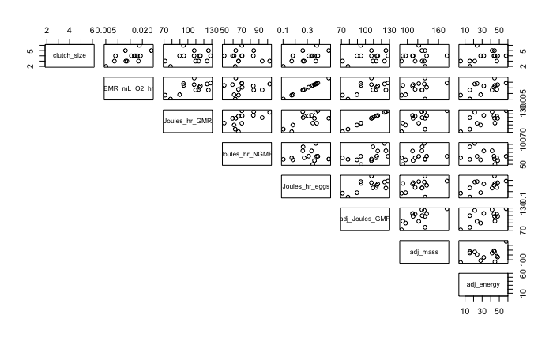

There are two that appear to have some collinearity, however, this is not a problem because they are showing the same thing. One of the variables is just the adjusted for clutch metabolic rates. We can will keep the adjusted metabolic rates.

```r
lm<- lm(adj_energy~ whole_clutch_mass+ clutch_size+ Joules_hr_eggs+adj_mass, data=adj_metabolic_rate)
```

[output not shown]

When we dredge the model we find that whole clutch mass held the greatest weight for a model. However, model 5 holds the same AIC so we will run the importance to determine what the most important factors are.

```r
importance(results)
```

```
                     whole_clutch_mass Joules_hr_eggs clutch_size adj_mass
Sum of weights:      0.54              0.44           0.16        0.16
N containing models:    8                 8              8           8
```

Again we see that whole clutch mass and egg metabolic rates are the most important factors to consider when looking at gravid female metabolic rates.

```r
lm1<- lm(Joules_hr_eggs ~ whole_clutch_mass+Joules_hr_eggs, data=adj_metabolic_rate )
```

```
the response appeared on the right-hand side and was droppedproblem with term 2 in model.matrix: no columns are assigned
```

```r
summary(lm1)
```

```
Call:
lm(formula = Joules_hr_eggs ~ whole_clutch_mass + Joules_hr_eggs,
    data = adj_metabolic_rate)

Residuals:
    Min      1Q  Median      3Q     Max
-0.1277 -0.0720  0.0219  0.0450  0.1552

Coefficients:
                  Estimate Std. Error t value Pr(>|t|)
(Intercept)        0.06486    0.10520    0.62     0.55
whole_clutch_mass  0.01701    0.00738    2.30     0.04 *
---
Signif. codes:  0 ‘***’ 0.001 ‘**’ 0.01 ‘*’ 0.05 ‘.’ 0.1 ‘ ’ 1

Residual standard error: 0.0867 on 12 degrees of freedom
Multiple R-squared:  0.307, Adjusted R-squared:  0.249
F-statistic: 5.31 on 1 and 12 DF,  p-value: 0.0399
```

```r
results<-dredge(lm1)
```

```
Fixed term is "(Intercept)"
```

```r
results
```

```
Global model call: lm(formula = Joules_hr_eggs ~ whole_clutch_mass + Joules_hr_eggs,
    data = adj_metabolic_rate)
---
Model selection table
   (Int) Jls_hr_egg whl_clt_mss df logLik  AICc delta weight
3 0.0649                  0.017  3   15.5 -22.5  0.00  0.356
4 0.0649          +       0.017  3   15.5 -22.5  0.00  0.356
1 0.3013                         2   12.9 -20.7  1.82  0.144
2 0.3013          +              2   12.9 -20.7  1.82  0.144
Models ranked by AICc(x)
```

After formatting the model to include only the whole clutch mass and metabolic rates of eggs we find that there are two models that best support this data. One that include onlu whole clutch mass and one that include wholes clutch mass and metabolic rates of the eggs.

```r
summary(adj_turtles)
```

```
 adj_Mass Status     emmean   SE df lower.CL upper.CL
      124 Gravid      106.1 4.14 23     97.5    114.6
      124 Non_Gravid   73.2 4.14 23     64.6     81.8

Confidence level used: 0.95
```

Table 1. A summary kable displaying group, adjusted means, lower and upper smr rates.

| adj_Mass | Status | emmean | SE | df | lower.CL | upper.CL |
| --- | --- | --- | --- | --- | --- | --- |
| 124 | Gravid | 106.1 | 4.14 | 23 | 97.5 | 114.6 |
| 124 | Non_Gravid | 73.2 | 4.14 | 23 | 64.6 | 81.8 |

```r
pairs(adj_turtles)
```

```
 contrast                        estimate   SE df t.ratio p.value
 124.5,Gravid - 124.5,Non_Gravid     32.9 5.85 23 5.620   <.0001
```

## Discussion

The results of this study determined gravid females have a signficantly higher metabolic rate than males and non-gravid females due to retaining eggs for an extended period of time. The study also found gravid females have elevated metabolic rates from their non-gravid metabolic rates. Neither of these findinfs were that suprising since producing and maintianing an offspring has some costs associated with it. The costs of oviductal egg retention although elevated at the start of each trial was not signficantly different throughout gravidity.The next steps in this study it to search literature to calculate the energy investments into other stages of reproduction such as, vitellogensis.

Postponement in nesting is an advantageous strategy in reproductive success, primarily in allowing for flexibility in the timing of oviposition (Ewert 1991; Rafferty and Reina 2012). Extending egg retention can increase survivability of offspring because it allows for gravid females to wait until environmental conditions are optimal. Habitat conditions fluctuate resulting in females not finding sufficient nesting areas or sufficient water reserves in their body to activate oviposition (Bulhman 1995). Thus oviductal egg retention would be energetically beneficial to prematurely depositing eggs and if at all possible producing another clutch. Waiting to nest until after a rainfall would decrease the chances of predation on nest (Spencer et al. 2001, Santos et al. 2016). Predation rates are further decreased when egg retention is extended because synchronized hatching occurs within and among nests (Plotkin et al. 1997). Extending egg retention ensures that eggs are all at the same stage of development (gastrula stage) before they are laid thus eggs or clutches hatch at the same time leading to increased survival rates among hatchlings due to predator dilution (Licht 1980, 1982; Licht et al. 1982; Owens and Morris 1985). Synchronized hatching further increases survivability and increases reproductive fitness of adult females by decreasing the energetic cost of nest escape by offspring (Rusli et al. 2016).